# Exploring Inversions using Python Karim K. Kardous

## **Initial Setup**

I start by configuring the Python environment using {reticulate}, specifying a custom virtual environment and ensuring required packages (matplotlib and pillow) are installed. This setup step ensures Python and R work seamlessly together; granted ‘seamlessly’ might be over-reaching, but at least for this case, fairly commonly used modules, it was the case.

```r
library(reticulate)
invisible(
  capture.output({
    Sys.setenv(RETICULATE_PYTHON = "py_venv/bin/python3.9")
    reticulate::use_python("py_venv/bin/python3.9", required = TRUE)
    })
)

invisible(
  capture.output({
  use_python("py_venv/bin/python3.9", required = TRUE)
  py_config()
  py_install(c('matplotlib', 'pillow'), envname = "py_venv", pip = TRUE)
  })
)
```

With this chunk executed, R is now ready to run Python code from the designated virtual environment with the necessary libraries installed.

## **Image Configuration and Setup using matplotlib & [Pillow](https://pypi.org/project/pillow/)**

To overcome issues with displaying Pillow images directly in Quarto, I used matplotlib.pyplot to render and show images in the document. This section defines utility functions for drawing images programmatically, including a basic black board, a chessboard, and an inversion-based pattern. Otherwise, you’d likely have to set figure parameters such as dimensions, axes, etc. for every image input, so I create the below function to reduce/eliminate this redundancy.

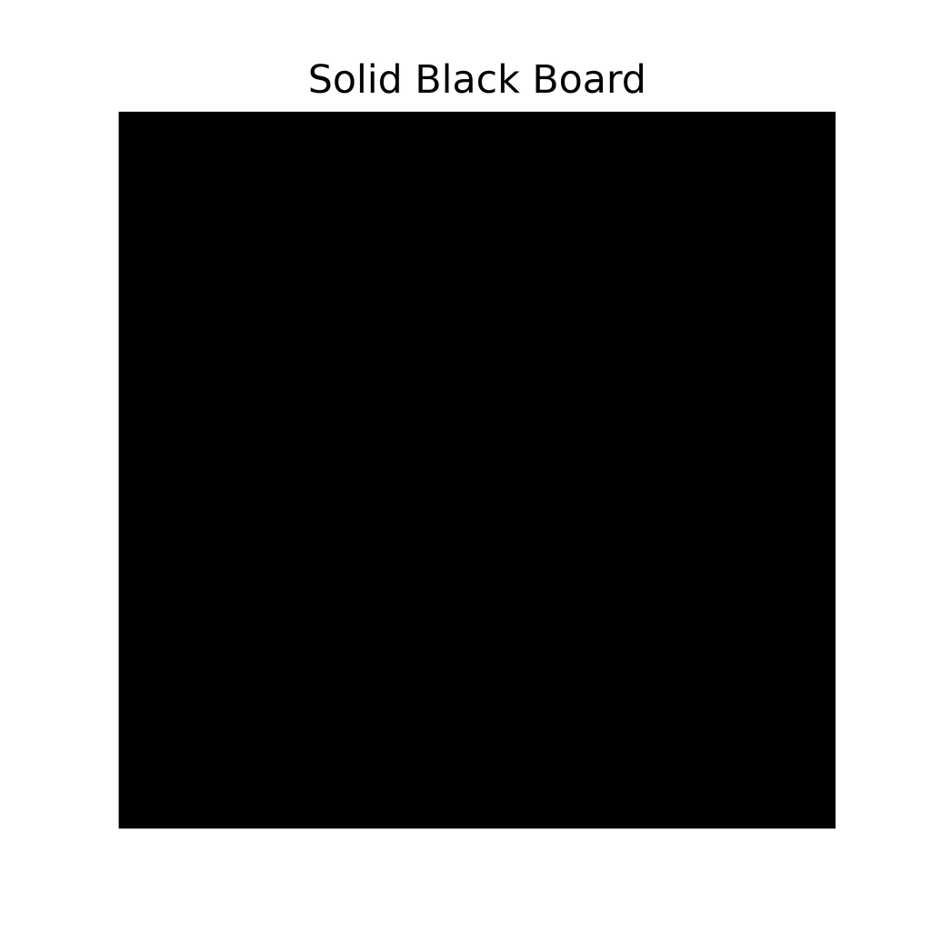

```python
from PIL import Image
import matplotlib.pyplot as plt
import math

# build a function to ease the plotting, reusable boilerplate basically with option to add additional arguments
def draw_figure(width=512, height=512, draw_func=None, title='Custom Board', figsize=(4, 4), background='white', **kwargs):

    board = Image.new('RGB', (width, height), background)
    # apply function if provided
    if draw_func:
        draw_func(board, width, height, **kwargs)

    plt.figure(figsize=figsize)
    plt.imshow(board)
    plt.axis('off')
    plt.title(title)
    plt.show()


def solid_unicolor_board(board, width, height):

  for x in range(width):
    for y in range(height):
      board.putpixel( (x, y), (0, 0, 0))

# define chess board pattern
def chess_pattern(board, width, height, square = 64, **kwargs):

  for x in range(width):
    for y in range(height):
      cx = x // square # or you can use math.floor(x / square) if index doesn't jstart at 0
      cy = y // square
      color = ((cx + cy) % 2) * 255
      board.putpixel((x, y), (color, color, color)) # black and white

# define an inversion
def inversion_pattern(board, width, height, R = 256, square = 64, **kwargs):

  for x in range(width):
    for y in range(height):
      x0 = x - width / 2 + .5  # define a center for x and one for y with offsets by half a pixel as technically the center is at .5, .5
      y0 = y - height / 2 + .5
      f = R**2 / (x0**2 + y0**2) # inverse factor or the radius squared divided by distance to center; addition to avoid zero division
      x1 = x0 * f
      y1 = y0 * f
      cx = math.floor(x1 / square)
      cy = math.floor(y1 / square)
      color = ((cx + cy) % 2) * 255
      # board.putpixel((x, y), (color, color, 0)) # black and yellow
      board.putpixel((x, y), (color, color, color)) # black and white

# outputting results/images
draw_figure(
  draw_func = solid_unicolor_board,
  title = 'Solid Black Board'
  )
```

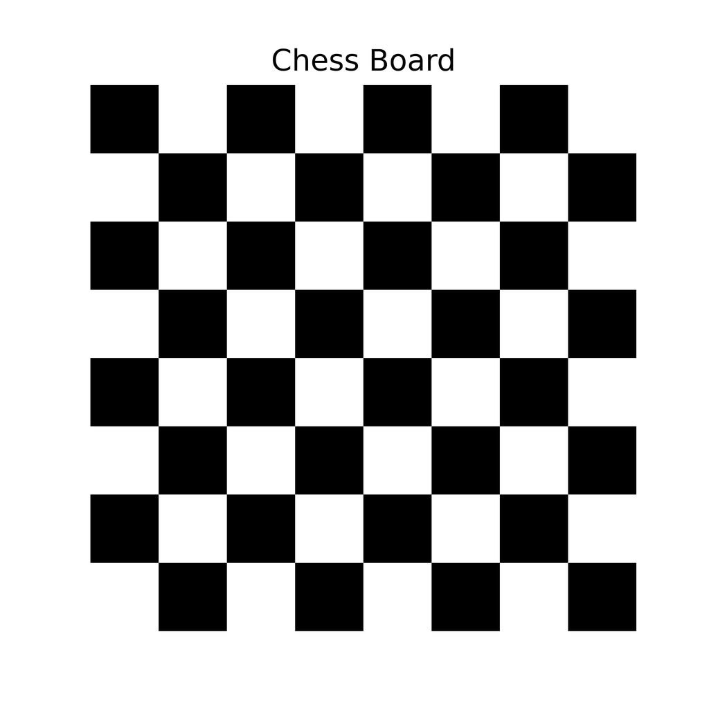

```python
draw_figure(
  draw_func = chess_pattern,
  title = 'Chess Board'
  )
```

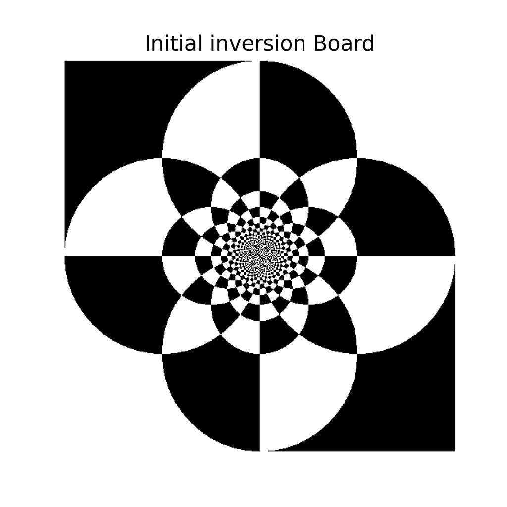

```python
draw_figure(
  draw_func = inversion_pattern,
  square = 256,
  title = 'Initial inversion Board'
  )
```

The closer you get to the center, the more stretched and squished things become visually (that’s if you really zoom it). This also explains why some areas look pixelated - the image doesn’t have enough detail at this size to show everything smoothly so next resolution is improved.

## **Improving Output Resolution**

To reduce the pixelation, especially towards the center of the image, I increase both the image dimensions and the square size; essentially increase resolution.

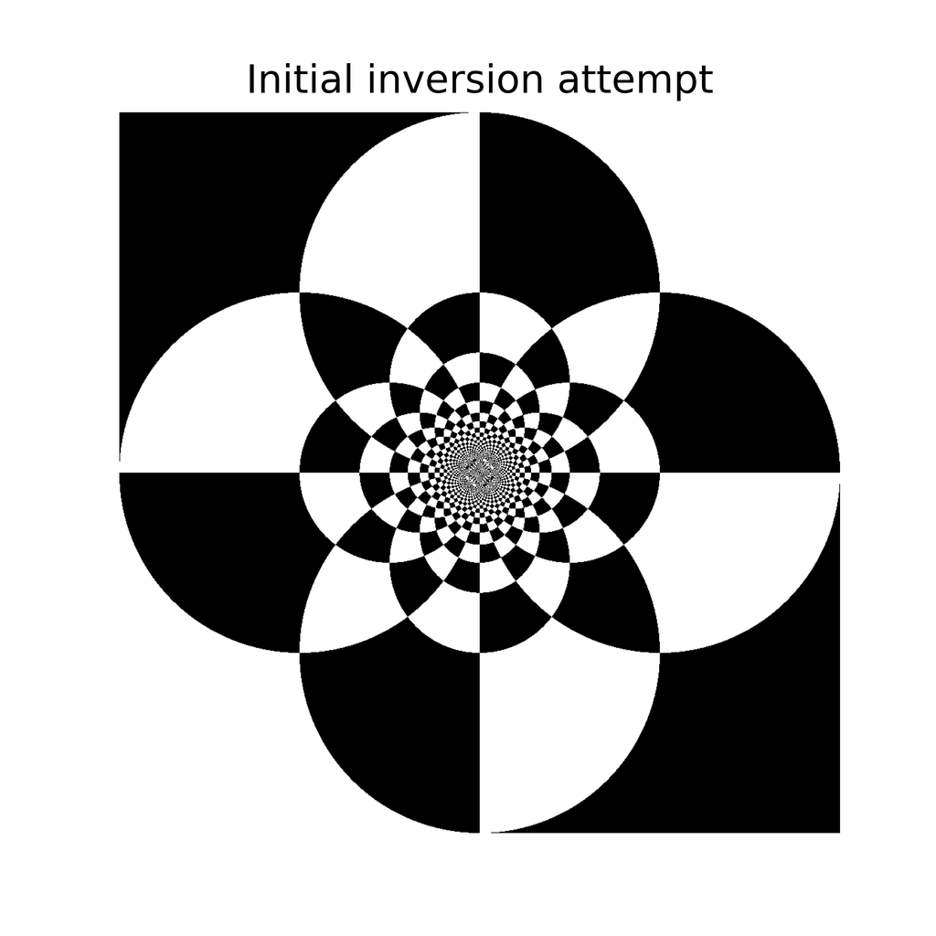

```python
draw_figure(
  draw_func = inversion_pattern,
  width = 512 * 2,
  height = 512 * 2,
  square = 256 * 2,
  R = 256 * 2,
  title = 'Initial inversion attempt'
  )
```

Doubling the dimensions already leads to significant visual improvement. The lift in clarity is again epscially visible towards the center/origin where distortion is most intense/visible.

## **Improving Output Resolution (by a factor of 10)**

Increasing resolution tenfold didn’t slow down render time that much so I go for it and it does look like we win in the trade.

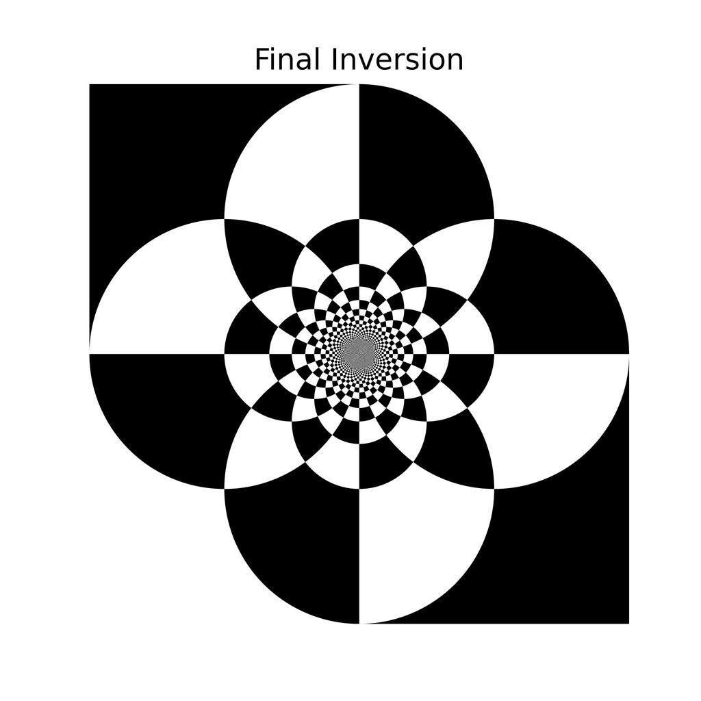

```python
draw_figure(
  draw_func = inversion_pattern,
  width = 512 * 10,
  height = 512 * 10,
  square = 256 * 10,
  R = 256 * 10,
  title = 'Final Inversion'
  )
```

Overall, I thought it was interesting, aesthetically if nothing else, to see how with a few lines of code, fairly intricate and cool-looking images get created. Thanks for reading !